# gencode_team_project

### Loading and setting up required data

```r
#wget ftp://ftp.ebi.ac.uk/pub/databases/gencode/Gencode_human/release_31/gencode.v31.basic.annotation.gtf.gz

library(tidyverse)
library(readr)

d = read_delim('gencode.v31.basic.annotation.gtf.gz',
               delim='\t', skip = 5, progress = F,
               col_names = F)
# skip : description pass
# col_name -> no columns. so F.

cols = c('chrom', 'source', 'feature_type', 'start', 'end', 'score', 'strand', 'phase', 'info')

d = read_delim('gencode.v31.basic.annotation.gtf.gz',
               delim='\t', skip = 5,
               progress = F,
               col_names = cols)
```

### 1. Counting the number of genes for each chromosome in GENCODE

In the `feature_type` column of raw `d` data, there are various rows containing `gene`, which contains obviously annotations for genes. We might want to subset those rows from the data frame.

```r
table(d$feature_type)
```

```
           CDS           exon           gene Selenocysteine    start_codon
        567862         744835          60603             96          57886
    stop_codon     transcript            UTR
         57775         108243         159202
```

```r
d1 = filter(d, feature_type == 'gene')
table(d1$chrom)
```

```
 chr1 chr10 chr11 chr12 chr13 chr14 chr15 chr16 chr17 chr18 chr19  chr2 chr20 chr21
 5471  2332  3360  3054  1397  2282  2221  2556  3060  1242  2992  4196  1457   872
chr22  chr3  chr4  chr5  chr6  chr7  chr8  chr9  chrM  chrX  chrY
 1384  3185  2651  2983  3059  3014  2482  2327    37  2422   567
```

We’ve subsetted only the `gene` row. Now we can count the number of genes for each chromosome in this data.

### 2. Counting the number of genes for each gene biotype per chromosome

Gene biotype data is stored in the `info` column. To count the number of genes for each gene biotype, we should extract the gene biotype information from the `info` column data and store it in a new column. For doing this work, we can use the `do.call` function:

```r
d1$gene_biotype <- as.character(do.call(rbind.data.frame, strsplit(d1$info, 'gene_type\\s+"'))[[2]])

d1$gene_biotype <- as.character(do.call(rbind.data.frame, strsplit( d1$gene_biotype, '\\"'))[[1]])
```

Now let’s check whether the code did work well.

```r
head(d1$gene_biotype)
```

```
[1] "transcribed_unprocessed_pseudogene" "unprocessed_pseudogene"
[3] "miRNA"                              "lncRNA"
[5] "miRNA"                              "lncRNA"
```

```r
table(d1$gene_biotype)
```

```
                         IG_C_gene                    IG_C_pseudogene
                                14                                  9
                         IG_D_gene                          IG_J_gene
                                37                                 18
                   IG_J_pseudogene                      IG_pseudogene
                                 3                                  1
                         IG_V_gene                    IG_V_pseudogene
                               144                                188
                            lncRNA                              miRNA
                             16840                               1881
                          misc_RNA                            Mt_rRNA
                              2212                                  2
                           Mt_tRNA             polymorphic_pseudogene
                                22                                 42
              processed_pseudogene                     protein_coding
                             10175                              19975
                        pseudogene                           ribozyme
                                18                                  8
                              rRNA                    rRNA_pseudogene
                                52                                500
                            scaRNA                              scRNA
                                49                                  1
                            snoRNA                              snRNA
                               942                               1901
                              sRNA                                TEC
                                 5                               1064
                         TR_C_gene                          TR_D_gene
                                 6                                  4
                         TR_J_gene                    TR_J_pseudogene
                                79                                  4
                         TR_V_gene                    TR_V_pseudogene
                               106                                 33
  transcribed_processed_pseudogene     transcribed_unitary_pseudogene
                               491                                129
transcribed_unprocessed_pseudogene    translated_processed_pseudogene
                               918                                  2
 translated_unprocessed_pseudogene                 unitary_pseudogene
                                 2                                 97
            unprocessed_pseudogene                           vaultRNA
                              2628                                  1
```

### 3. Identifying length of gene by type of chromosome and gene biotype

Let’s store the gene length information in a new colum `gene_length`. The length can be calculated by `end` and `start` data.

```r
d1$gene_length <- (d1$end - d1$start)
d2 <- select(d1, chrom, gene_biotype, gene_length)
```

Grouped the datas by gene biotype and chrom data for further processing:

```r
d2_type <- d2 %>% group_by(gene_biotype) %>% summarize(mean_length = mean(gene_length), sd_length = sd(gene_length)) %>% arrange(mean_length)

d2_chrom <- d2 %>% group_by(chrom) %>% summarize(mean_length = mean(gene_length), sd_length = sd(gene_length)) %>% arrange(mean_length)
```

### 4. Data visualization

```r
library(ggplot2)

d2_chrom %>% arrange(chrom)
```

| chrom | mean_length | sd_length |
| --- | --- | --- |
| chr1 | 29803.3255 | 79777.3659 |
| chr10 | 37471.8516 | 106568.3454 |
| chr11 | 27727.6286 | 86856.5225 |
| chr12 | 31896.2004 | 77907.0978 |
| chr13 | 39763.3350 | 105285.0143 |
| chr14 | 28713.5372 | 85553.9506 |
| chr15 | 31473.9018 | 75642.5396 |
| chr16 | 23906.5246 | 79465.5912 |
| chr17 | 21073.4827 | 55999.3950 |
| chr18 | 38585.1908 | 95201.2403 |

[output cut: 15 more lines]

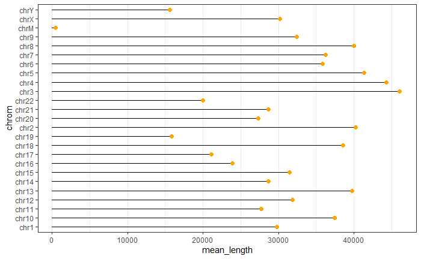

```r
ggplot(d2_chrom, aes(x = mean_length, y = chrom)) +
  geom_segment(aes(yend = chrom),xend = 0) +
  geom_point(size = 2, color = "orange") +
  theme_bw(base_family = "AppleGothic") +
  theme(panel.grid.major.y = element_blank())
```

```r
d2_type %>% arrange(gene_biotype)
```

| gene_biotype | mean_length | sd_length |
| --- | --- | --- |
| IG_C_gene | 3825.78571 | 2.869432e+03 |
| IG_C_pseudogene | 1011.44444 | 1.607438e+03 |
| IG_D_gene | 22.00000 | 6.612278e+00 |
| IG_J_gene | 65.55556 | 4.508452e+01 |
| IG_J_pseudogene | 54.00000 | 5.000000e+00 |
| IG_pseudogene | 305.00000 | NaN |
| IG_V_gene | 1793.06944 | 1.467295e+04 |
| IG_V_pseudogene | 378.34043 | 1.471474e+02 |
| lncRNA | 32514.57334 | 8.230832e+04 |
| miRNA | 80.87241 | 1.712317e+01 |

[output cut: 30 more lines]

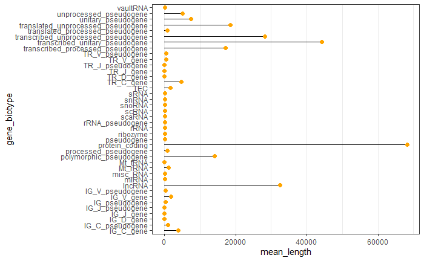

```r
ggplot(d2_type, aes(x = mean_length,y = gene_biotype)) +
  geom_segment(aes(yend = gene_biotype),xend = 0) +
  geom_point(size = 2, color = "orange") +
  theme_bw(base_family = "AppleGothic") +
  theme(panel.grid.major.y = element_blank())
```

### Exercise

1. What is the average length of human genes?

```r
mean(d2$gene_length)
```

```
[1] 32628.02
```

2. Is the distribution of gene length differed by autosomal and sex chromosomes? Please calculate the quantiles (0%, 25%, 50%, 75%, 100%) of the gene length for each group.

```r
my_summary <- function(d2){
  x <- quantile(d2$gene_length, c(0, 0.25, 0.5, 0.75, 1))
  data_frame(min = x[1], Q1 = x[2], median = x[3], Q3 = x[4], max = x[5])
}

d2_chrom_quan <- d2 %>%
 group_by(chrom) %>%
  do(my_summary(.))
```

```
`data_frame()` is deprecated, use `tibble()`.
```

```r
d2_chrom_quan
```

| chrom | min | Q1 | median | Q3 | max |
| --- | --- | --- | --- | --- | --- |
| chr1 | 40 | 566.50 | 4477.0 | 25584.50 | 1551956 |
| chr10 | 53 | 571.50 | 4257.5 | 31054.25 | 1825171 |
| chr11 | 49 | 816.00 | 3780.5 | 19781.00 | 2172910 |
| chr12 | 27 | 596.50 | 4507.5 | 28492.00 | 1258197 |
| chr13 | 47 | 484.00 | 3027.0 | 30812.00 | 1475061 |
| chr14 | 7 | 338.50 | 1827.0 | 19123.00 | 1697917 |
| chr15 | 16 | 474.00 | 3349.0 | 26148.00 | 949079 |
| chr16 | 50 | 763.50 | 3693.5 | 19847.25 | 2473536 |
| chr17 | 27 | 670.25 | 4047.0 | 18157.50 | 1161877 |
| chr18 | 49 | 578.25 | 3090.0 | 27870.50 | 1195706 |

[output cut: 15 more lines]

3. Is the distribution of gene length differed by gene biotype? Please calculate the quantiles (0%, 25%, 50%, 75%, 100%) of the gene length for each group.

```r
my_summary <- function(d2){
  x <- quantile(d2$gene_length, c(0, 0.25, 0.5, 0.75, 1))
  data_frame(min = x[1], Q1 = x[2], median = x[3], Q3 = x[4], max = x[5])
}

d2_biotype_quan <- d2 %>%
  group_by(gene_biotype) %>%
  do(my_summary(.))

d2_biotype_quan
```

| gene_biotype | min | Q1 | median | Q3 | max |
| --- | --- | --- | --- | --- | --- |
| IG_C_gene | 440 | 476.25 | 4588.5 | 5477.75 | 8913 |
| IG_C_pseudogene | 247 | 312.00 | 316.0 | 733.00 | 5210 |
| IG_D_gene | 10 | 16.00 | 19.0 | 30.00 | 36 |
| IG_J_gene | 32 | 37.25 | 48.0 | 66.75 | 175 |
| IG_J_pseudogene | 49 | 51.50 | 54.0 | 56.50 | 59 |
| IG_pseudogene | 305 | 305.00 | 305.0 | 305.00 | 305 |
| IG_V_gene | 293 | 494.50 | 521.0 | 570.75 | 176627 |
| IG_V_pseudogene | 27 | 270.00 | 415.5 | 457.50 | 791 |
| lncRNA | 67 | 1872.75 | 6271.5 | 24773.50 | 1375316 |
| miRNA | 40 | 69.00 | 79.0 | 90.00 | 179 |

[output cut: 30 more lines]